# 1D Stochastic Dynamic Programming for Coypu Regulation

Continuous abundance discretized onto a grid, solved as an MDP with value iteration

Olivier Gimenez

25 February 2026

# 1 Overview

This document provides a compact **1D stochastic dynamic programming (SDP) / Markov decision process (MDP)** example for coypu (ragondin) regulation. The objective is to find an optimal control policy $u^\*(N)$ that trades off:

- **Damages** that increase with population size $N$ (e.g., crops, dikes, nuisance),
- **Management costs** that increase with control effort $u$,
- An optional **penalty** if $N$ exceeds a tolerable threshold $N_{\text{tol}}$.

**State**: total abundance $N$ (1D, discretized).  
**Action**: control effort $u \in [0,1]$ (discretized).  
**Dynamics**: logistic growth minus removals due to control.  
**Reward**: negative total cost $R(N,u)=-(\text{damage}+\text{cost}+\text{penalty})$.  
**Solution**: infinite-horizon discounted value iteration via **`MDPtoolbox`**.

# 2 Setup

```r
library(MDPtoolbox)
set.seed(666)
```

# 3 State and action grids

We discretize abundance on a finite grid $\{0, 20, \dots, K\}$ and effort on $[0,1]$.

```r
# Carrying capacity: upper bound defining the support for N
K <- 2000

# Discretized state space for abundance N
seq_N <- seq(0, K, by = 20)
S <- length(seq_N)

# Discretized action space for control effort u in [0,1]
seq_u <- seq(0, 1, by = 0.05)
A <- length(seq_u)

S; A
```

```
## [1] 101
```

```
## [1] 21
```

# 4 Parameters (toy, to calibrate)

```r
# Intrinsic growth rate (toy)
r <- 0.9

# Controls how quickly removal fraction increases with effort u
alpha <- 1.5

# Threshold above which the situation becomes "unacceptable"
N_tol <- 400
```

# 5 Helper functions

```r
# Clamp into [lo, hi]
clamp <- function(x, lo, hi) pmin(pmax(x, lo), hi)

# Project a continuous next value onto the discrete grid by nearest neighbor
round_to_grid <- function(x, grid) {
  grid[which.min((grid - x)^2)]
}

# Removal fraction as a saturating function of effort u: q(u) = 1 - exp(-alpha*u)
q_u <- function(u) 1 - exp(-alpha * u)
```

# 6 Population dynamics

We use a simple deterministic 1-step model (e.g., yearly):

$$N_{t+1} = N_t + rN_t\left(1-\frac{N_t}{K}\right) - q(u)N_t.$$

```r
step_fun <- function(N, u) {
  Nnext <- N + r * N * (1 - N / K) - q_u(u) * N
  clamp(Nnext, 0, K)
}
```

# 7 Reward function

Reward is defined as negative costs:

- **Damage**: increasing convex function of $N$,
- **Control cost**: increasing convex function of $u$,
- **Penalty**: soft constraint if $N > N_{\text{tol}}$.

```r
reward_fun <- function(N, u) {

  # Damages (toy): linear + quadratic
  damage <- 0.1 * N + 0.001 * N^2

  # Management cost: convex in u
  cost <- 50 * u + 200 * u^2

  # Penalty above threshold (soft constraint)
  penalty <- if (N > N_tol) 2000 * (N - N_tol) / N_tol else 0

  # Reward = negative costs (MDPtoolbox maximizes)
  -(damage + cost + penalty)
}
```

# 8 Build the transition kernel and reward matrix

`MDPtoolbox` expects:

- $P$: transition probability array with dimensions $[S, S, A]$,
- $R$: reward matrix $[S, A]$.

Here we discretize the continuous next abundance with `round_to_grid()`, so transitions are **deterministic** on the grid (for each $(s,a)$, exactly one next state has probability 1).

```r
P <- array(0, dim = c(S, S, A))
R <- matrix(0, nrow = S, ncol = A)

for (s in seq_len(S)) {

  N <- seq_N[s]

  for (a in seq_len(A)) {

    u <- seq_u[a]

    # continuous next abundance
    Nnext <- step_fun(N, u)

    # snap to nearest grid point
    Ndisc <- round_to_grid(Nnext, seq_N)

    # translate into next-state index
    s_next <- which(seq_N == Ndisc)

    # deterministic transition
    P[s, s_next, a] <- 1

    # immediate reward
    R[s, a] <- reward_fun(N, u)
  }
}

mdp_check(P, R)
```

```
## [1] ""
```

# 9 Solve the infinite-horizon discounted MDP

We solve by value iteration. The discount factor must satisfy $0 \le \gamma < 1$.

```r
sol <- mdp_value_iteration(P, R, discount = 0.99, epsilon = 1e-6)
```

```
## [1] "MDP Toolbox: iterations stopped, epsilon-optimal policy found"
```

```r
str(sol)
```

```
## List of 6
##  $ V       : num [1:101] 0 -4440 -13860 -19660 -22140 ...
##  $ policy  : int [1:101] 1 8 15 18 19 20 21 21 21 16 ...
##  $ iter    : num 2413
##  $ time    : 'difftime' num 2.76906991004944
##   ..- attr(*, "units")= chr "secs"
##  $ epsilon : num 1e-06
##  $ discount: num 0.99
```

# 10 Optimal policy $u^\*(N)$

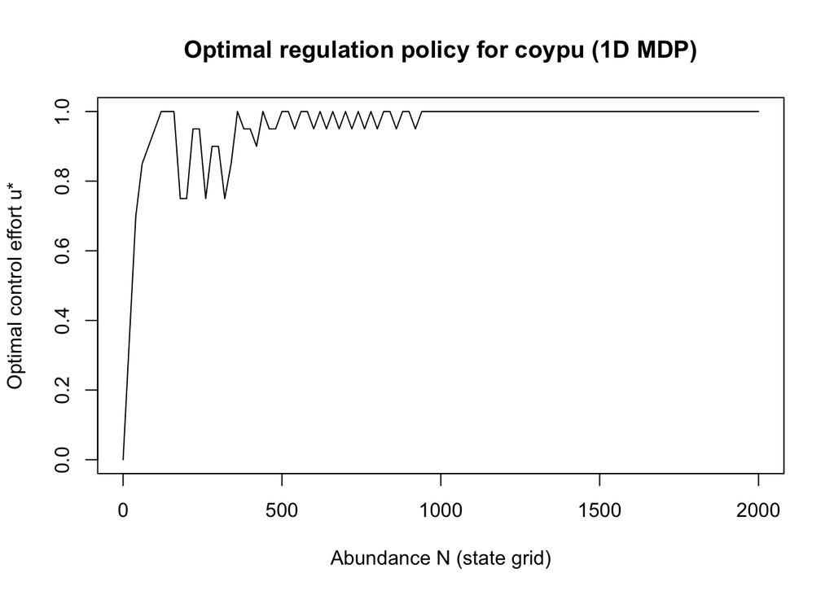

```r
u_star <- seq_u[sol$policy]

plot(seq_N, u_star, type = "l",
     xlab = "Abundance N (state grid)",
     ylab = "Optimal control effort u*",
     main = "Optimal regulation policy for coypu (1D MDP)")
```

# 11 Simulate a trajectory under the optimal policy

Because we discretize and transitions are deterministic on the grid, the simulated trajectory is deterministic given $N_0$.

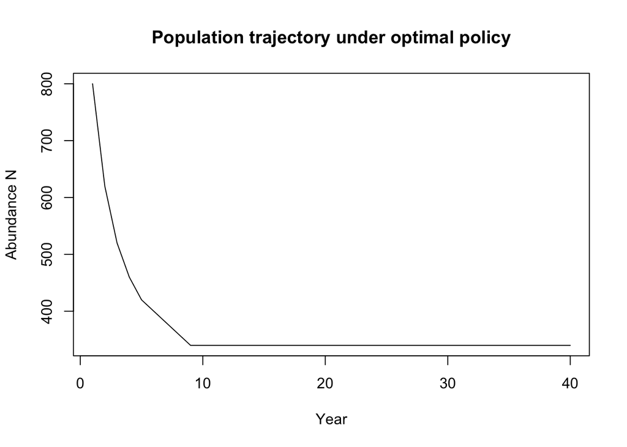

```r
simulate_policy <- function(N0, n_years = 30) {

  N_path <- numeric(n_years)
  u_path <- numeric(n_years)
  reward_path <- numeric(n_years)

  N_path[1] <- clamp(N0, 0, K)

  for (t in 1:(n_years - 1)) {

    # nearest state
    s <- which.min((seq_N - N_path[t])^2)

    # optimal action
    a <- sol$policy[s]
    u <- seq_u[a]

    u_path[t] <- u
    reward_path[t] <- reward_fun(N_path[t], u)

    # step forward and snap to grid
    Nnext <- step_fun(N_path[t], u)
    N_path[t + 1] <- round_to_grid(Nnext, seq_N)
  }

  data.frame(
    year = 1:n_years,
    N = N_path,
    u = u_path,
    reward = reward_path
  )
}

traj <- simulate_policy(N0 = 800, n_years = 40)

plot(traj$year, traj$N, type = "l",
     xlab = "Year",
     ylab = "Abundance N",
     main = "Population trajectory under optimal policy")
```

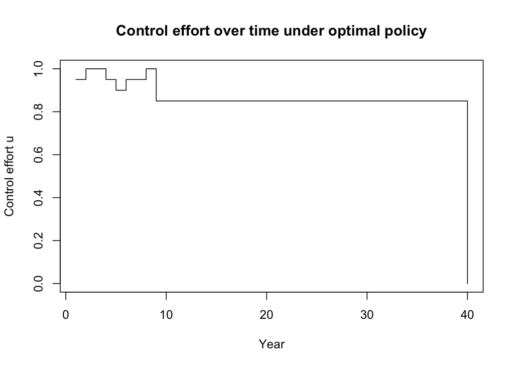

```r
plot(traj$year, traj$u, type = "s",
     xlab = "Year",
     ylab = "Control effort u",
     main = "Control effort over time under optimal policy")
```

# 12 Why do we need `round_to_grid()`?

The ecological dynamics `step_fun()` returns a **continuous** value (e.g., $N_{t+1}=437.6$), but an MDP requires a **finite discrete** state space. `round_to_grid()` maps the continuous value onto the closest grid point (e.g., $437.6 \mapsto 440$):

```r
x <- 437.6
grid <- c(400, 420, 440, 460)
c(x = x, rounded = round_to_grid(x, grid))
```

```
##       x rounded
##   437.6   440.0
```

Conceptually, discretization implies a precision/runtime trade-off:

- **Finer grid**: more precise policy, higher computational cost.
- **Coarser grid**: faster computation, more approximation error.